# R Markdown: Reproducible Report in Data Science

Danielle Meza

2026-08-27 10:34:29

# 1 R Markdown

R Markdown is a format for writing reproducible, dynamic reports with R. Use it to embed R code and results into slideshows, PDFs, HTML documents, Word files, and more.

# 2 Structure

1. YAML Header
2. Text Area
3. Code chunk

# 3 Workflow

1. **Open** – Open a file that uses the .Rmd extension.
2. **Write** – Write content with the easy-to-use R Markdown syntax.
3. **Embed** – Embed R code that creates output to include in the report.
4. **Render** – Replace R code with its output and transform the report into a slideshow, PDF, HTML, or MS Word file (done by clicking **Knit**).

# 4 Text Area Formatting Tools

Plain text just types normally. End a line with two trailing spaces to force a new paragraph/line break.

*italics* and *italics*

**bold** and **bold**

superscript<sup>2</sup>

strikethrough

Hyperlink: [CCIDM](https://www.cpp.edu/cba/customer-insights-lab/index.shtml)

# 5 Header 1

## 5.1 Header 2

### 5.1.1 Header 3

#### 5.1.1.1 Header 4

##### 5.1.1.1.1 Header 5

###### 5.1.1.1.1.1 Header 6

endash: – emdash: — inline equation: $A = \pi*r^2$ slide break:

> Block quote
1. Ordered list 1
2. Ordered list 2
   - sub-item 1
   - sub-item 2

| Table Header | Second Header |
| --- | --- |
| Table Cell | Cell 2 |
| Cell 3 | Cell 4 |

# 6 YAML Header Explained

> A YAML header is a set of key: value pairs at the start of your file. Begin and end the header with a line of three dashes (`---`). (From the Rmd cheatsheet: https://www.rstudio.com/wp-content/uploads/2015/02/rmarkdown-cheatsheet.pdf)

My YAML header above is different from the plain default RStudio generates automatically — that’s because I customized the `output` options, and those settings control how the knitted HTML file will look.

- **date**: `2026-08-27 10:34:29`
  - This prints the current date/time every time I knit the file, instead of a hardcoded date.
  - Can be customized several ways:
    - date-time: `2026-08-27 10:34:29.540538`
    - Day, Month, date, Year: `Thursday, August, 27, 2026`
    - m/d/Y format: `08/27/2026`
- **code_folding**: show
  - Lets readers collapse/expand code chunks in the knitted HTML, but shows the code by default.
- **toc**: yes
  - Turns on the table of contents. It gets hyperlinks in the HTML output so readers can jump to sections quickly.
- **toc_depth**: 4
  - Table of contents will show up to 4 levels of headings deep.
- **toc_float**: (nested, collapsed: false)
  - Moves the TOC from the top of the document to a floating sidebar that stays visible as you scroll.
  - By default the floating TOC starts collapsed (not showing all headings) — setting `collapsed: false` under it keeps it expanded.
- **highlight**: espresso
  - Controls the syntax-highlight style of code chunks — espresso gives a black background for the code area.
- **theme**: journal
  - Overall visual theme of the knitted document. Lots of built-in options to try (cosmo, flatly, journal, united, etc.).
- **number_sections**: yes
  - Auto-numbers your headings, which is why I don’t need to manually number sections above (e.g. “1 R Markdown”, “2 Structure”, etc.)
  - Try swapping these values and re-knitting to see what changes.

# 7 Embed Codes

## 7.1 Code chunk

### 7.1.1 Sample

Insert a new code chunk with **Cmd + Option + I** (Mac)

```r
# use ctl + Enter simultaneous to execute a line
# Use # to comment out a code

# install.packages("tidyverse")
library(tidyverse)

# install.packages("palmerpenguins")
library(palmerpenguins)
penguins
```

```
## # A tibble: 344 × 8
##    species island    bill_length_mm bill_depth_mm flipper_length_mm body_mass_g
##    <fct>   <fct>              <dbl>         <dbl>             <int>       <int>
##  1 Adelie  Torgersen           39.1          18.7               181        3750
##  2 Adelie  Torgersen           39.5          17.4               186        3800
##  3 Adelie  Torgersen           40.3          18                 195        3250
##  4 Adelie  Torgersen           NA            NA                  NA          NA
##  5 Adelie  Torgersen           36.7          19.3               193        3450
##  6 Adelie  Torgersen           39.3          20.6               190        3650
##  7 Adelie  Torgersen           38.9          17.8               181        3625
##  8 Adelie  Torgersen           39.2          19.6               195        4675
##  9 Adelie  Torgersen           34.1          18.1               193        3475
## 10 Adelie  Torgersen           42            20.2               190        4250
## # ℹ 334 more rows
## # ℹ 2 more variables: sex <fct>, year <int>
```

```r
dim(penguins)
```

```
## [1] 344   8
```

```r
# install.packages("skimr")
skimr::skim(penguins)
```

Data summary

| Name | penguins |
| --- | --- |
| Number of rows | 344 |
| Number of columns | 8 |
| _______________________ |  |
| Column type frequency: |  |
| factor | 3 |
| numeric | 5 |
| ________________________ |  |
| Group variables | None |

**Variable type: factor**

| skim_variable | n_missing | complete_rate | ordered | n_unique | top_counts |
| --- | --- | --- | --- | --- | --- |
| species | 0 | 1.00 | FALSE | 3 | Ade: 152, Gen: 124, Chi: 68 |
| island | 0 | 1.00 | FALSE | 3 | Bis: 168, Dre: 124, Tor: 52 |
| sex | 11 | 0.97 | FALSE | 2 | mal: 168, fem: 165 |

**Variable type: numeric**

| skim_variable | n_missing | complete_rate | mean | sd | p0 | p25 | p50 | p75 | p100 | hist |
| --- | --- | --- | --- | --- | --- | --- | --- | --- | --- | --- |
| bill_length_mm | 2 | 0.99 | 43.92 | 5.46 | 32.1 | 39.23 | 44.45 | 48.5 | 59.6 | ▃▇▇▆▁ |
| bill_depth_mm | 2 | 0.99 | 17.15 | 1.97 | 13.1 | 15.60 | 17.30 | 18.7 | 21.5 | ▅▅▇▇▂ |
| flipper_length_mm | 2 | 0.99 | 200.92 | 14.06 | 172.0 | 190.00 | 197.00 | 213.0 | 231.0 | ▂▇▃▅▂ |
| body_mass_g | 2 | 0.99 | 4201.75 | 801.95 | 2700.0 | 3550.00 | 4050.00 | 4750.0 | 6300.0 | ▃▇▆▃▂ |
| year | 0 | 1.00 | 2008.03 | 0.82 | 2007.0 | 2007.00 | 2008.00 | 2009.0 | 2009.0 | ▇▁▇▁▇ |

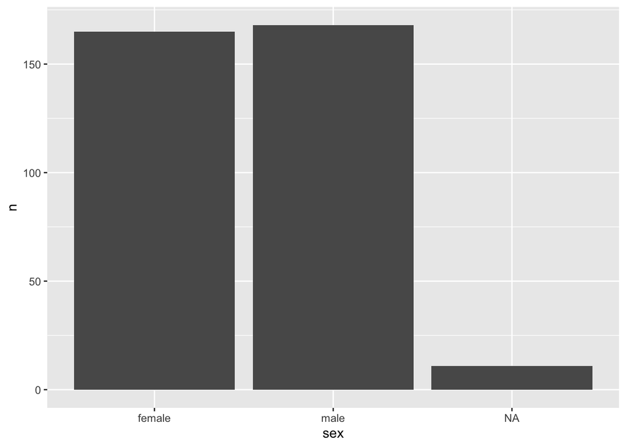

```r
# Sex distribution
penguins %>%
  count(sex) %>%
  ggplot(aes(sex, n)) +
  geom_col()
```

```r
# Number of male
sum(penguins$sex == "male", na.rm = TRUE)
```

```
## [1] 168
```

```r
# Total observation
nrow(penguins)
```

```
## [1] 344
```

```r
# Percent of Males
m_per <- round((sum(penguins$sex == "male", na.rm = TRUE) / nrow(penguins)) * 100, digits = 1)

# Percent of Females
f_per <- round((sum(penguins$sex == "female", na.rm = TRUE) / nrow(penguins)) * 100, digits = 1)
```

### 7.1.2 Code chunk options

Chunk options (like `message=FALSE, warning=FALSE` in the `{r penguins, ...}` header above) control what shows up in the knitted output for that specific chunk — e.g. suppressing package-load messages/warnings so they don’t clutter the report. For the full list of options, see https://yihui.org/knitr/options/

## 7.2 Inline coding

Inline code lets you drop a single R value directly into a sentence of regular text, instead of only showing results inside a chunk. Syntax is a single backtick, the letter `r`, your code, then a closing backtick.

- Sample characteristics: There are 344 penguins in the data, 48.8% of which are males and 48% of which are females.

(Notice this sentence will always stay accurate even if the underlying data changes — that’s the “reproducible” part of reproducible reporting: re-knit and the numbers update automatically instead of me manually retyping them.)

# 8 Navigation

- Outline (right side) — jumps between headings in your source file
- Status bar (bottom) — shows your current cursor location/section

# 9 Expectations for Organizing Your Assignment Report with an Rmd File

## 9.1 DS-L01-2 Rmd Principle Assignment

(The instructor’s own version of this template says “M01-1 Principle Assignment” here, since he reuses this file across different courses — swap in your actual assignment name so the heading matches this assignment.)

# 10 References

- R Markdown cheatsheet: https://www.rstudio.com/wp-content/uploads/2015/02/rmarkdown-cheatsheet.pdf
- knitr chunk options: https://yihui.org/knitr/options/